# quakr

Jared Brabazon

2017-05-01

# Introduction

This package contains five functions that allow the visualization of earthquake data. These functions include (1) mapull, (2) beniplot, (3) adj_beniplot,(4) geocoord_km, and (5) polar_transform. The main purpose is to easily define Wadati-Benioff Zones for subducting slabs. However, this package provides the tools to visualize any earthquake data. This package, while not fully dependent on USGS datasets, was built with the intention of exporting desired datasets from https://earthquake.usgs.gov/earthquakes/search/ (see appendix at end of document for a tutorial on obtaining USGS data).

# Plan view mapping

In geology, it is widely accepted that most earthquakes occur on plate boundaries. Therefore, it can be very informative to map the spatial distribution of earthquakes in plan view. This allows for zones of seismicity to easily be delineated. The mapull function can help to spatially plot these earthquakes on top of a google map. For example, if I wanted to see the spatial distribution of earthquakes along the subduction zone in Chile, I could go to the USGS database ([via](https://earthquake.usgs.gov/earthquakes/search/)) and export earthquake data as a csv for the years and magnitude specified. Importing USGS data, I get something that looks like the table below (Note that I have used a dataset “chile”" that is incorporated in the quakr package):

```
##                        time latitude longitude depth mag
## 1  2017-04-13T03:42:53.500Z -31.0348  -71.3978 43.21 5.4
## 2  2017-03-31T18:44:38.790Z -30.7288  -71.5379 33.35 5.2
## 3  2017-03-27T03:03:32.060Z -36.2368  -71.7591 85.59 5.0
## 4  2017-03-13T15:05:55.950Z -30.4330  -71.4005 45.90 5.1
## 5  2017-03-10T06:22:20.770Z -30.5797  -72.0795 14.07 5.2
## 6  2017-02-26T08:59:16.670Z -28.9602  -71.5883 34.69 5.0
## 7  2017-02-16T07:02:05.500Z -30.1677  -72.1093  9.84 5.4
## 8  2017-02-12T16:21:11.430Z -27.8715  -71.3402 16.17 5.1
## 9  2017-02-03T00:52:26.450Z -33.0883  -69.7164 10.00 5.4
## 10 2016-12-16T23:11:43.220Z -30.4233  -71.6189 35.61 5.2
```

Using the mapull function, I can map these data points on a google map by depth or by magnitude (both shown below). Note that the bounds of the map are automatically calculated based on the longitude and latitude of the data points.

[figure not shown]

```r
mapull(data, magnitude = FALSE)
```

[figure not shown]

```r
mapull(data, magnitude = TRUE)
```

By looking at the maps, it appears that the trend of the earthquakes from the USGS database trend around 15 degrees from North (top of map). This can be inferred to be the subduction zone. The depth color gradient helps to see differences in earthquake depth in relation to their location. Here, we see that there is a trend of deeper earthquakes inland than that of the coast. This is likely due to events occuring with the subducting slab at depth. By allowing magnitude = TRUE in the function, we can now view the data in regards to magnitude. The magnitude map helps to see where larger earthquakes tend to occur. It seems that most of the larger earthquakes tend to occur closer to the coast.

# Visualizing earthquakes with depth

Now that we have a good understanding of these earthquakes in plan view, it can be important to visualize the data with their respective depths. This is important specifically in defining seismic zones such as the Wadati-Benioff zone. The best method to visualizing these earthquakes is by using the beniplot and adj_beniplot functions. The beniplot function allows for the visualization of data along a cross-section perpendicular to north. This may be beneficial in some cases, however, it is important to note that faults striking any degree from north will be displayed obliquely. The beniplot function allows for four options in visualizing the data. The data can be in units of kilometers or longitude. Also, the data can be toggled to view the correlation of magnitude with depth.

If, for example, we wanted to define the Wadati-Benioff zone for the subducting slab along Chile as mapped above. Using beniplot, the zone can be decently defined despite looking at the data obliquely.

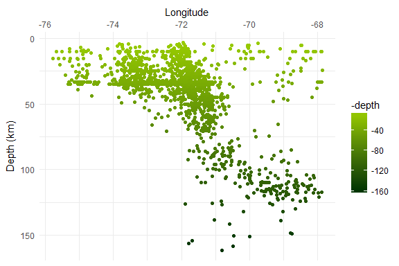

```r
beniplot(data, units = "lon", magnitude = FALSE)
```

We see what appears to look like the subducting slab over the longitude specified. There appears to be a relatively linear zone of seismicity which helps to define the Wadati-Benioff zone. Now that the zone is relatively well defined, we may want to see if there is clustering of events of larger magnitude. Using beniplot we yield the following.

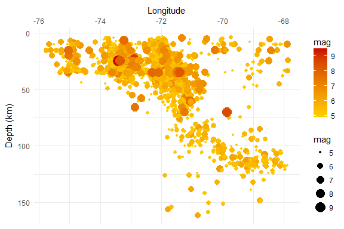

```r
beniplot(data, units = "lon", magnitude = TRUE)
```

Say that we now would like to convert from longitude to kilometers along the cross-section. Using beniplot we yield the following.

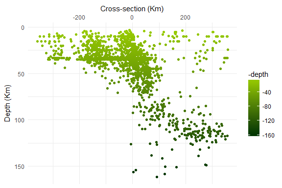

```r
beniplot(data, units = "km", magnitude = FALSE)
```

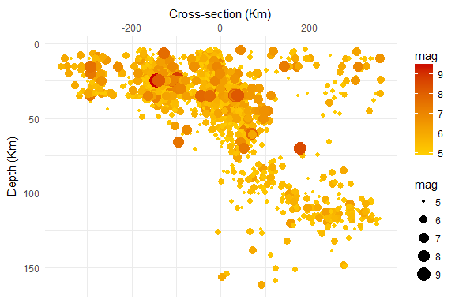

```r
beniplot(data, units = "km", magnitude = TRUE)
```

It is important to note that data using this beniplot function may be seen obliquely as the cross-section is perpendicular to north. To account for the strike of the fault of interest, one can use the adj_beniplot function. For example, I know that the strike of the subduction zone along the coast of Chile is striking nearly 13 degrees from north. To account for this strike, I use the adj_beniplot as follows.

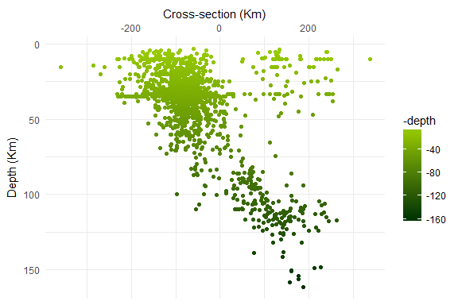

```r
adj_beniplot(data, strike = 13, magnitude = FALSE)
```

Now I have a much clearer plot that truly defines the Wadati-Benioff zone of the slab perpendicular to the strike. If I now wanted to view the correlation of magnitude and depth along the cross-section perpendicular to strike, I could use the following.

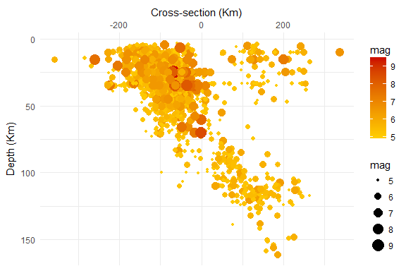

```r
adj_beniplot(data, strike = 13, magnitude = TRUE)
```

In conclusion, it is important to understand what cross-sectional area I would like to plot. Knowing what the beniplot and adj_beniplot functions do will help to get a crisp image of cross-section desired.

# Unit analysis and data rotation

Unit analysis is an important component of defining the Wadati-Benioff zone. Sometimes, we like to have our spatial data in geocoordinates of latitude and longitude. However, at times we may want to convert such points to an (x,y) projection in kilometers. For example, to acount for a fault’s strike from north, we need to rotate the data points. In order to rotate the data points, they need to have an origin about which to rotate. The geocoord_km function projects the latitude and longitude in terms of kilometers about an origin. If we used the Chile earthquake set as shown above, we could convert the values and receive a dataframe with the lat,lon and the new x,y values.

```r
new_values <- geocoord_km(data)
head(new_values)
```

```
##            x         y latitude longitude
## 1  38.284865  470.5992 -31.0348  -71.3978
## 2  25.565610  504.6248 -30.7288  -71.5379
## 3   5.483533 -107.8368 -36.2368  -71.7591
## 4  38.039740  537.5163 -30.4330  -71.4005
## 5 -23.604612  521.2040 -30.5797  -72.0795
## 6  20.989947  701.2842 -28.9602  -71.5883
```

With the new values, we can now perform a matrix rotation on the data to change its orientation. Using matrix algebra, we can solve for the new x,y values for a given degree of rotation.

$$\left [\begin{array}{cc} \cos\theta & -\sin\theta \\ \sin\theta & \cos\theta \end{array} \right] \left[\begin{array}{c} x\\y \end{array}\right] = \left[\begin{array}{c} new x\\new y \end{array}\right]$$

The newx and newy values are defined as the following equations:

$x\cos\theta - y\sin\theta = newx$

$x\sin\theta + y\cos\theta = newy$

Using these equations, any cartesian data can be rotated by $\theta$. If we were looking at our plan view map of Chile with earthquake spatial data, we would want to account for the strike. The maps generated from google denote the top of the map as north. Unfortunately we cannot rotate the map. Therefore, we need to rotate the earthquake data to allow the strike of the fault to be perpendicular to north. Again, as I know the fault in Chile is striking 13 degrees from north, I can use the following:

```r
rot_values <- polar_transform(new_values, rotation = 13, plots = FALSE)
head(rot_values)
```

```
##        new.x     new.y          x         y
## 1  -68.55815  467.1500  38.284865  470.5992
## 2  -88.60552  497.4423  25.565610  504.6248
## 3   29.60100 -103.8395   5.483533 -107.8368
## 4  -83.85007  532.2968  38.039740  537.5163
## 5 -140.24501  502.5357 -23.604612  521.2040
## 6 -137.30264  688.0320  20.989947  701.2842
```

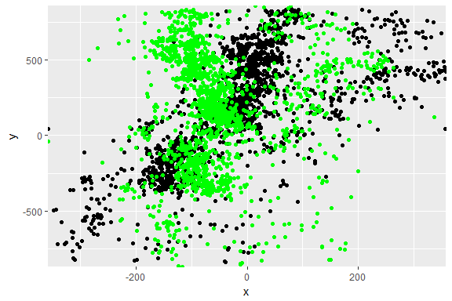

```r
polar_transform(new_values, rotation = 13, plots = TRUE)
```

The result is the original x,y points in km generated by the geocoord_km function shown in black and the new rotated points shown in green. A dataframe can also be made of the new values. This works for any dataframe with cartesian points labled as x and y.

# Conclusion

The quakr package allows the visualization of earthquake data as well as offers tools for data transformation. This package was designed to determine Wadati-Benioff zones along subducting slabs. However, it may provide useful in analyzing any earthquake datasets.

# Appendix

The following appendix serves as a help guide to obtain data from https://earthquake.usgs.gov/earthquakes/search/. As was mentioned above, this package can use any earthquake data that includes latitude, longitude, depth, and magnitude. The USGS site is ideal as it allows one to export .csv files that contain all of these parameters. These .csv files can easily be read into R as dataframes. It is to be noted that the website may change with time. This appendix was written on 5/1/2017 and may become inaccurate upon the changing of the USGS website.

### Step 1

The first step in obtaining earthquake data is to go to https://earthquake.usgs.gov/earthquakes/search/. Once at the site, a search can be conducted. Tailor your search to your needs by adjusting the range of magnitudes desired as well as the range of dates. Then select the button “Draw Rectangle on Map.”

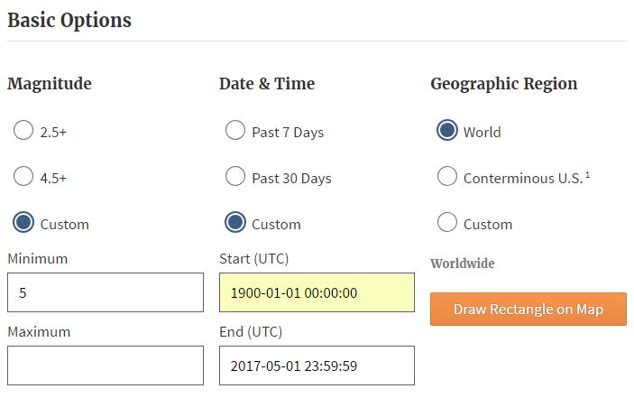

### Step 2

The next step is to select the area of interest. Draw a rectangle on the map that covers the area you would like to obtain earthquake information from. See the below image.

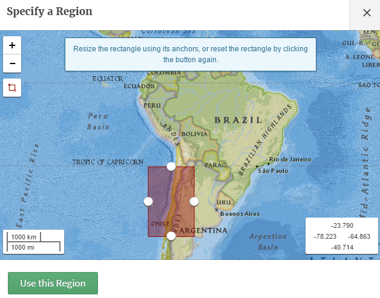

### Step 3

The last step is to export the data selected as a .csv file. To do this, simply expand the Output Options tab and select CSV. Now save the file to a known location and read it into R as a dataframe.

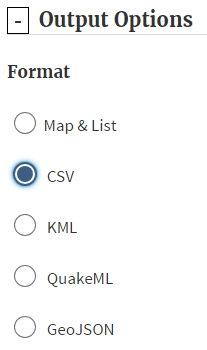

#### It is to be noted that a dataset “chile” has been added to the package to use for examples.